# Assignment 9

Ernie Vilela

10/28/2020

### **ASSIGNMENT DESCRIPTION**

Tasks to be completed in this Assignment:

Use the data set “/Data/GradSchool_Admissions.csv”

You will explore and model the predictors of graduate school admission

- the “admit” column is coded as 1=success and 0=failure
- the other columns are the GRE score, the GPA, and the rank of the undergraduate institution, where I is “top-tier.”

Document your data explorations, figures, and conclusions in a reproducible R-markdown report

Upload your self-contained R project, including knitted HTML report, to GitHub in your Assignment_9 directory

### **RESOURCES USED**

Tidiverse, modelr, MASS, and patchwork libraries were used for completing this assignment.

```r
library(tidyverse)
library(modelr)
library(MASS)
library(patchwork)
```

### **LOADING THE DATA**

The following loads the Graduate School Admissions data set into a dataframe called ‘gradData’:

```r
gradData <- read.csv("../../Data/GradSchool_Admissions.csv")
```

### **CLEANING UP THE DATA**

We had to turn the integers into logical values (the 1 and 0 into TRUE and FALSE, respectively)

```r
#Turning the integers into logical.
gradData$admit <- as.logical(gradData$admit)
```

We had to turn the ranking numbers into factors

```r
#Turning the ranking to factor
gradData$rank <- factor(gradData$rank)
```

### **SUMMARIZING THE DATA**

The following a summary of the Graduate School Admissions data set:

```r
summary(gradData)
```

```
##    admit              gre             gpa        rank
##  Mode :logical   Min.   :220.0   Min.   :2.260   1: 61
##  FALSE:273       1st Qu.:520.0   1st Qu.:3.130   2:151
##  TRUE :127       Median :580.0   Median :3.395   3:121
##                  Mean   :587.7   Mean   :3.390   4: 67
##                  3rd Qu.:660.0   3rd Qu.:3.670
##                  Max.   :800.0   Max.   :4.000
```

### **MODELING PREDICTORS**

We will proceed to model the predictors of graduate school admissions:

#### **MODEL 1**

This model is a logistic regression. In this model we look at a generalized linear model of the data taking into account the gre, gpa, and the rank.

```r
mod1 <- glm(formula=admit ~ gre + gpa + rank, data=gradData, family = "binomial")
summary(mod1)
```

```
##
## Call:
## glm(formula = admit ~ gre + gpa + rank, family = "binomial",
##     data = gradData)
##
## Deviance Residuals:
##     Min       1Q   Median       3Q      Max
## -1.6268  -0.8662  -0.6388   1.1490   2.0790
##
## Coefficients:
##              Estimate Std. Error z value Pr(>|z|)
## (Intercept) -3.989979   1.139951  -3.500 0.000465 ***
## gre          0.002264   0.001094   2.070 0.038465 *
## gpa          0.804038   0.331819   2.423 0.015388 *
## rank2       -0.675443   0.316490  -2.134 0.032829 *
## rank3       -1.340204   0.345306  -3.881 0.000104 ***
## rank4       -1.551464   0.417832  -3.713 0.000205 ***
## ---
## Signif. codes:  0 '***' 0.001 '**' 0.01 '*' 0.05 '.' 0.1 ' ' 1
##
## (Dispersion parameter for binomial family taken to be 1)
##
##     Null deviance: 499.98  on 399  degrees of freedom
## Residual deviance: 458.52  on 394  degrees of freedom
## AIC: 470.52
##
## Number of Fisher Scoring iterations: 4
```

Predictions were created in order to estimate the probability of students that will be admitted to graduate school based on their GPA scores, GRE scores, and their school ranking. A generalized linear model was used to assess the variables:

```r
#adding some predictions (the predictions [pred] represent the probabilty of the students that will make it into grad school based on the variables gpa, rank, and gre)
gradDataPredictions <- add_predictions(gradData, mod1, type="response")
```

##### MODEL 1 - Figure 1.1) Graduate School Admissions based on GPA

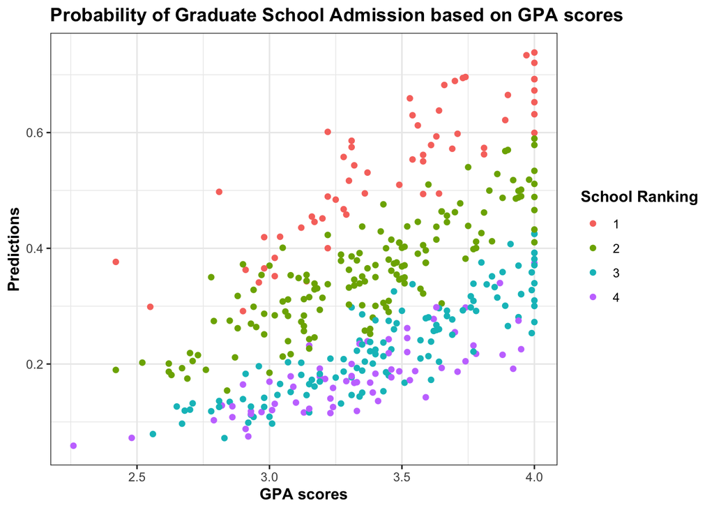

```r
#plotting the predictions based on GPA scores
ggplot(gradDataPredictions, aes(x=gpa, y=pred, color=rank))+
  geom_point()+
  labs(x= "GPA scores", y= "Predictions", title= "Probability of Graduate School Admission based on GPA scores", color= "School Ranking")+
  theme_bw()+
  theme(title=element_text(face="bold"))
```

This graph shows that there is a high probability of admission for those students who are of “top-tier” institutions (School ranking #1). The lower the ranking of the school, the lower the probability of potential graduate school admission.

##### MODEL 1 - Figure 1.2) Graduate School Admissions based on GRE

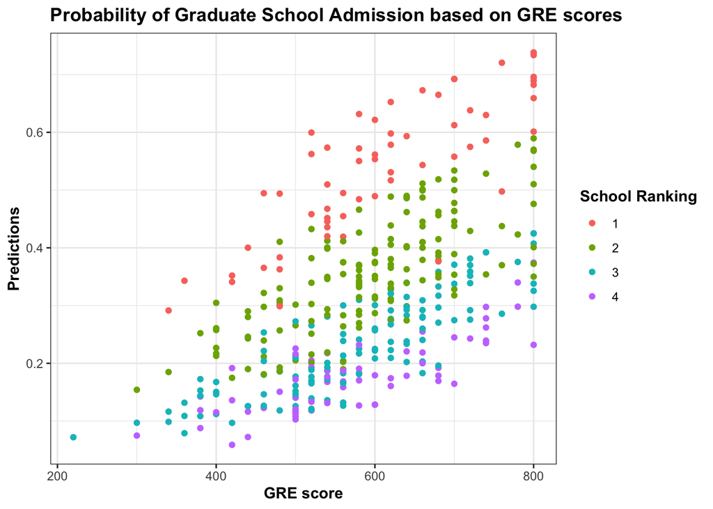

```r
#plotting the predictions based on GRE scores
ggplot(gradDataPredictions, aes(x=gre, y=pred, color=rank))+
  geom_point()+
  labs(x= "GRE score", y= "Predictions", title= "Probability of Graduate School Admission based on GRE scores", color= "School Ranking")+
  theme_bw()+
  theme(title=element_text(face="bold"))
```

#### **MODEL 2**

This model is a logistic regression. In this model we look at a generalized linear model of the data taking into account the gre, gpa, the rank, and also their interactions between them.

```r
mod2 <- glm(formula=admit ~ gre * gpa * rank, data=gradData, family = "binomial")
summary(mod2)
```

```
##
## Call:
## glm(formula = admit ~ gre * gpa * rank, family = "binomial",
##     data = gradData)
##
## Deviance Residuals:
##     Min       1Q   Median       3Q      Max
## -1.7664  -0.8518  -0.6437   1.0565   2.2283
##
## Coefficients:
##                 Estimate Std. Error z value Pr(>|z|)
## (Intercept)   -35.999967  16.048971  -2.243   0.0249 *
## gre             0.052274   0.025176   2.076   0.0379 *
## gpa            10.242737   4.716620   2.172   0.0299 *
## rank2          33.954685  18.430800   1.842   0.0654 .
## rank3          14.608867  20.838126   0.701   0.4833
## rank4          13.935601  24.587935   0.567   0.5709
## gre:gpa        -0.014640   0.007294  -2.007   0.0447 *
## gre:rank2      -0.054299   0.029213  -1.859   0.0631 .
## gre:rank3      -0.020111   0.033741  -0.596   0.5511
## gre:rank4      -0.023092   0.040135  -0.575   0.5651
## gpa:rank2     -10.105436   5.447632  -1.855   0.0636 .
## gpa:rank3      -4.978875   6.062873  -0.821   0.4115
## gpa:rank4      -4.666198   7.120462  -0.655   0.5123
## gre:gpa:rank2   0.015725   0.008524   1.845   0.0651 .
## gre:gpa:rank3   0.006381   0.009675   0.659   0.5096
## gre:gpa:rank4   0.006888   0.011536   0.597   0.5505
## ---
## Signif. codes:  0 '***' 0.001 '**' 0.01 '*' 0.05 '.' 0.1 ' ' 1
##
## (Dispersion parameter for binomial family taken to be 1)
##
##     Null deviance: 499.98  on 399  degrees of freedom
## Residual deviance: 450.39  on 384  degrees of freedom
## AIC: 482.39
##
## Number of Fisher Scoring iterations: 5
```

Predictions were created in order to estimate the probability of students that will be admitted to graduate school based on their GPA scores, GRE scores, and their school ranking. A generalized linear model was used to assess the variables.

```r
#adding some predictions (the predictions [pred] represent the probabilty of the students that will make it into grad school based on the variables gpa, rank, and gre)
gradDataPredictions2 <- add_predictions(gradData, mod2, type="response")
```

##### MODEL 2 - Figure 2.1) Graduate School Admissions based on GPA

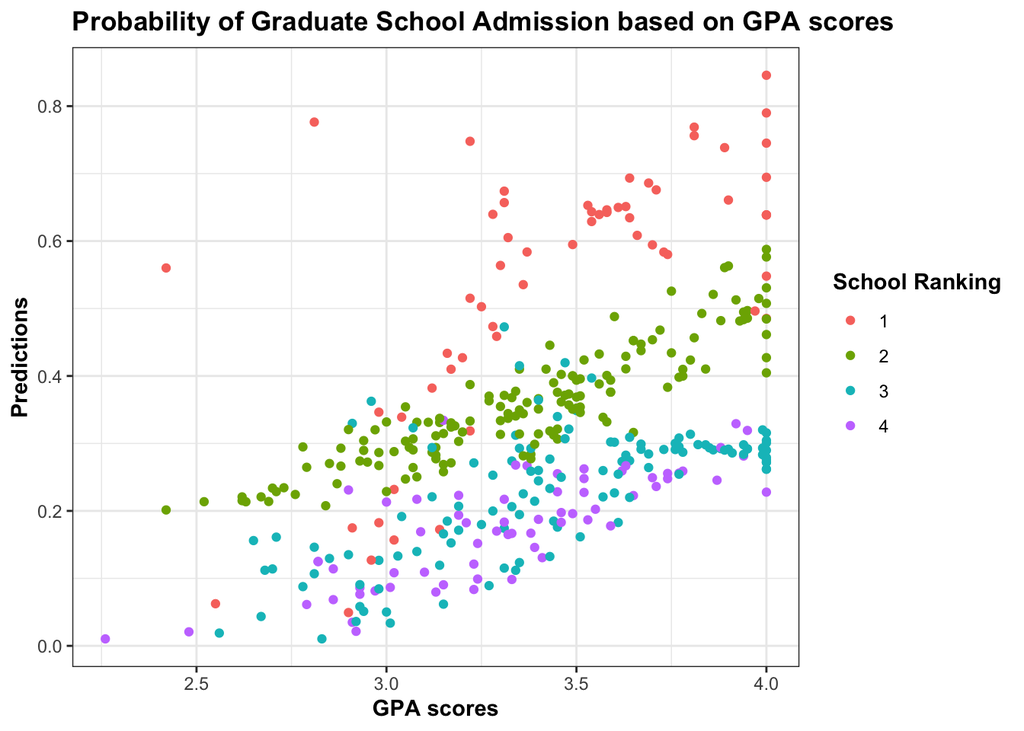

```r
#plotting the predictions based on GPA scores
ggplot(gradDataPredictions2, aes(x=gpa, y=pred, color=rank))+
  geom_point()+
  labs(x= "GPA scores", y= "Predictions", title= "Probability of Graduate School Admission based on GPA scores", color= "School Ranking")+
  theme_bw()+
  theme(title=element_text(face="bold"))
```

This graph shows that there is a high probability of admission for those students who are of “top-tier” institutions (School ranking #1). The lower the ranking of the school, the lower the probability of potential graduate school admission.

##### MODEL 2 - Figure 2.2) Graduate School Admissions based on GRE

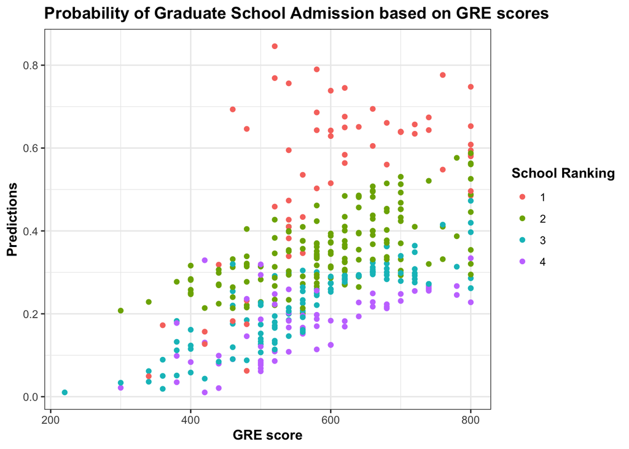

```r
#plotting the predictions based on GRE scores
ggplot(gradDataPredictions2, aes(x=gre, y=pred, color=rank))+
  geom_point()+
  labs(x= "GRE score", y= "Predictions", title= "Probability of Graduate School Admission based on GRE scores", color= "School Ranking")+
  theme_bw()+
  theme(title=element_text(face="bold"))
```

### **COMPARING MODELS**

We will proceed to compare Model 1 and 2:

*We will find the mean square of each model, in order to find the model with the best fit line.*

The mean square of model 1:

```r
mod1mean <- mean(residuals(mod1)^2)
mod1mean
```

```
## [1] 1.146294
```

The mean square of model 2:

```r
mod2mean <- mean(residuals(mod2)^2)
mod2mean
```

```
## [1] 1.125965
```

The lowest number will conform to the best fit model. In this case, that will be model 2.

#### GATHERING THE PREDICTIONS

*We have made predictions for both model 1 and model 2, as shown previously. We will now consolidate our data.*

```r
mod_full <- gather_predictions(gradData, mod1, mod2)
head(mod_full)
```

```
##   model admit gre  gpa rank       pred
## 1  mod1 FALSE 380 3.61    3 -1.5671256
## 2  mod1  TRUE 660 3.67    3 -0.8848442
## 3  mod1  TRUE 800 4.00    1  1.0377118
## 4  mod1  TRUE 640 3.19    4 -1.5273305
## 5  mod1 FALSE 520 2.93    4 -2.0081113
## 6  mod1  TRUE 760 3.00    2 -0.5323458
```

#### GRAPHING THE BEST MODEL

**Figure 3.1)** *Looking at the importance of* **GPA scores** *in admissions for the best model:*

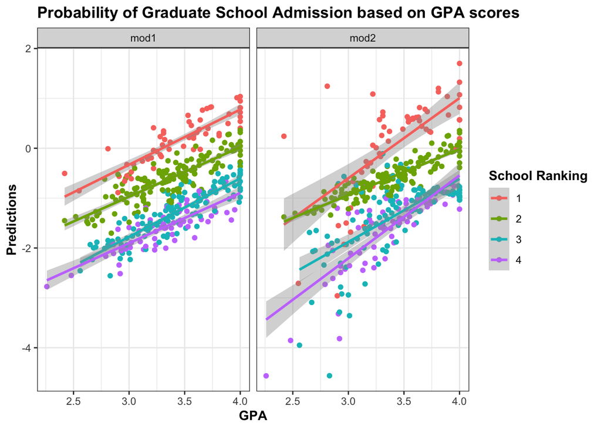

```r
ggplot(mod_full,aes(x=gpa,col=rank)) +
  geom_point(aes(y=pred)) +
  geom_smooth(method = "lm", aes(y=pred)) +
  labs(x= "GPA", y= "Predictions", title= "Probability of Graduate School Admission based on GPA scores", color= "School Ranking")+
  facet_wrap(~model) +
  theme_bw()+
   theme(title=element_text(face="bold"))
```

These graphs support the earlier graphs of each model, in which there was significant importance of the high school ranking and high GPA score in the likelihood of those applicants to be admitted into graduate school.

**Figure 3.2)** *Looking at the importance of* **GRE scores** *in admissions for the best model:*

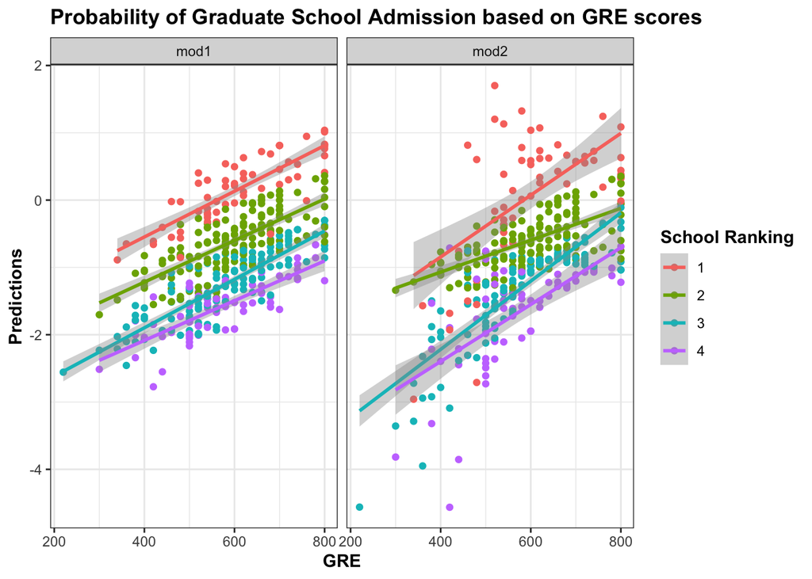

```r
ggplot(mod_full,aes(x=gre,col=rank)) +
  geom_point(aes(y=pred)) +
  geom_smooth(method = "lm", aes(y=pred)) +
  labs(x= "GRE", y= "Predictions", title= "Probability of Graduate School Admission based on GRE scores", color= "School Ranking")+
  facet_wrap(~model) +
  theme_bw()+
   theme(title=element_text(face="bold"))
```

**Ernie Vilela - 2020**  
*Peer Reviewed by Trevor Millar*  
[Click to here visit Github Repository](https://github.com/ErnieVc/Data_Course_VILELA)